# Data Analysis and Visualization with Pandas, NumPy, and Matplotlib

This notebook provides a comprehensive introduction to data analysis and visualization using pandas, numpy, and matplotlib. We will cover basic data analysis techniques and how to create various types of plots.

## Prerequisites

Make sure you have python installed. I recommend using the Anaconda distribution which comes with python other necessary libraries. You can install it from [here](https://www.anaconda.com/products/distribution).

## Environment

You can start working right away, however, I advise you to create a virtual environment for this project. A virtual environment is a self-contained directory that contains a Python installation for a particular version of Python, plus a number of additional packages. Its like a separate space on your computer where you can install and manage packages for a specific project without affecting other projects or the system's main Python installation. Think of it like a sandbox where you can play around with different tools and libraries needed for a project without worrying about messing up other projects or your main setup. This means you can have different environments for different projects, each with its own set of dependencies (libraries, packages, etc.).

You can create a virtual environment using the following command in your terminal:

```
conda create -n myenvironmentname python=3.10
```

Activate you enviroment means you are telling your terminal to use the python version and packages installed in that environment for the current project. Activate the environment using:

```
conda activate myenvironmentname
```

Now open a jupyter notebook through the anaconda navigator app or by running the following command in your terminal:

```
jupyter notebook
```

If you use virtual studio code or another IDE, you can simply create a new notebook (create a file with the extension .ipynb) and start working. Make sure to select the correct kernel (the virtual environment you created) for your notebook.

## Google Colab

**If you don't want to do all of this, you can simply use google colab which is a free cloud service provided by google. You can run jupyter notebooks on the cloud without having to install anything. It is also a great way to colaborate. But make sure you save and download all our important files because Colab does not store your files permanently. You can access it [here](https://colab.research.google.com/).**

## 1. Importing Libraries

First, let's import the necessary libraries.

```python
import pandas as pd
import numpy as np
import matplotlib.pyplot as plt
```

- **pandas** : Think of pandas as a supercharged spreadsheet that you can control with code. It helps you organize and analyze your data efficiently. You can use pandas to load data from various file formats (CSV, Excel, etc.), perform data cleaning, manipulation, and analysis.
- **numpy**: numpy is like a powerful calculator that can handle lots of numbers at once, making it easy to perform complex mathematical calculations on large datasets. numpy is often used for performing mathematical operations on large datasets, such as calculating the mean, median, standard deviation, and more.
- **matplotlib**: matplotlib is like an artist's toolkit for drawing graphs and charts, allowing you to visualize your data in various ways to see patterns and insights. You can use matplotlib to create line graphs, scatter plots, bar charts, histograms, and many other types of visualizations to help you understand your data better.

## 1.1 Generating a random dataset.

We will generate a random dataset to work with. Skip this step if you have your own dataset.

```python
# Create a sample dataset
np.random.seed(0)
data = {
    'A': np.random.normal(loc=50, scale=5, size=100),
    'B': np.random.normal(loc=30, scale=10, size=100),
    'C': np.random.normal(loc=70, scale=15, size=100),
    'D': np.random.randint(10, 100, size=100)
}

df = pd.DataFrame(data)

# Save the dataset to a CSV file for use in the notebook
df.to_csv('sample_data.csv', index=False)
```

## 2. Loading Data

Let's load the sample dataset we created for this notebook. To read a csv file, we use the `pd.read_csv()` function. We will also display the first few rows of the dataset using the `head()` function.

```python
# Load the dataset
df = pd.read_csv('sample_data.csv')
df.head()
```

|  | A | B | C | D |
| --- | --- | --- | --- | --- |
| 0 | 58.820262 | 48.831507 | 64.462272 | 41 |
| 1 | 52.000786 | 16.522409 | 66.409312 | 60 |
| 2 | 54.893690 | 17.295150 | 86.494894 | 56 |
| 3 | 61.204466 | 39.693967 | 79.828956 | 43 |
| 4 | 59.337790 | 18.268766 | 79.601973 | 22 |

## 3. Basic Data Analysis with pandas

Let's perform some basic data analysis to understand the dataset. Our dataframe (spreadsheet) is in the variable `df`. `df` is a dataframe object with a 2-d tabular data structure with labeled axes (rows and columns). We can perform various operations on this dataframe to analyze the data. To get a quick overview of the data, we can use the `info()` function.

```python
# Basic info
df.info()
```

```
<class 'pandas.core.frame.DataFrame'>
RangeIndex: 100 entries, 0 to 99
Data columns (total 4 columns):
 #   Column  Non-Null Count  Dtype
---  ------  --------------  -----
 0   A       100 non-null    float64
 1   B       100 non-null    float64
 2   C       100 non-null    float64
 3   D       100 non-null    int64
dtypes: float64(3), int64(1)
memory usage: 3.2 KB
```

- **Float**: A float is a number that has a decimal point. For example, 3.14 or 2.0.
- **Integer**: An integer is a whole number without a decimal point. For example, 5 or -3.
- **Object**: An object is a general term for any data that isn’t a float or integer, such as text (strings) or more complex data structures like lists or DataFrames.
- **Non-Null Count**: This tells us how many non-null values are present in each column. A non-null value is a value that is present in the dataset and is not empty.
- **Datetime**: A datetime is a data type that represents dates and times. For example, 2022-01-01 12:00:00.

```python
# Basic statistics
df.describe()
```

|  | A | B | C | D |
| --- | --- | --- | --- | --- |
| count | 100.000000 | 100.000000 | 100.000000 | 100.000000 |
| mean | 50.299040 | 30.820130 | 69.111516 | 55.930000 |
| std | 5.064799 | 10.398795 | 14.351979 | 25.791023 |
| min | 37.235051 | 7.765968 | 28.411109 | 11.000000 |
| 25% | 46.780717 | 22.545702 | 61.051532 | 35.000000 |
| 50% | 50.470481 | 30.246549 | 68.869617 | 56.000000 |
| 75% | 53.685387 | 38.474799 | 78.079850 | 79.000000 |
| max | 61.348773 | 53.831448 | 104.558750 | 99.000000 |

### 3.1. Dropping Rows and Columns

You might want to drop rows or columns based on certain conditions. Here's how you can do it

```python
# Dropping rows with missing values
df_cleaned = df.dropna()

# Dropping specific columns
df_cleaned = df.drop(columns=['C'])
```

### 3.2. Renaming Columns

Renaming columns can make your data more readable or align it with naming conventions.

```python
# Renaming columns
df_cleaned = df_cleaned.rename(columns={'A': 'Feature_1', 'B': 'Feature_2'})
```

### 3.3. Dealing with NaNs (Missing Values)

Handling missing data is crucial. You can either drop these rows, fill them with a specific value, or interpolate.

```python
# Filling NaNs with a specific value (e.g., the mean of the column)
df_filled = df.fillna(df.mean())

# Interpolating missing values
df_interpolated = df.interpolate()
```

### 3.4. Calculating Mean and Averaging Across DataFrames

Calculating the mean of a DataFrame or averaging across multiple DataFrames can be useful.

```python
# lets create 3 dataframes first

df1 = pd.DataFrame({'A': [1, 2, 3, 4, 5], 'B': [10, 20, 30, 40, 50]})
df2 = pd.DataFrame({'A': [6, 7, 8, 9, 10], 'B': [60, 70, 80, 90, 100]})
df3 = pd.DataFrame({'A': [11, 12, 13, 14, 15], 'B': [110, 120, 130, 140, 150]})
```

```python
# Mean of a single DataFrame
df_mean = df.mean()

# Averaging multiple DataFrames (assuming they have the same structure)
df_list = [df1, df2, df3]  # List of DataFrames
df_average = pd.concat(df_list).groupby(level=0).mean()
```

```python
df_mean
```

```
A    50.299040
B    30.820130
C    69.111516
D    55.930000
dtype: float64
```

```python
df_average
```

|  | A | B |
| --- | --- | --- |
| 0 | 6.0 | 60.0 |
| 1 | 7.0 | 70.0 |
| 2 | 8.0 | 80.0 |
| 3 | 9.0 | 90.0 |
| 4 | 10.0 | 100.0 |

### 3.5 Combining DataFrames

You can concatenate or merge DataFrames based on a common key.

```python
# Lets create a new dataframe
df4 = pd.DataFrame({'A': [1, 2, 3, 4, 5], 'B': [10, 20, 30, 40, 50]})
```

```python
# Concatenating DataFrames
df_combined = pd.concat([df1, df2], axis=1)  # axis=0 for rows, axis=1 for columns

# Merging DataFrames on a common column
df_merged = pd.merge(df1, df4, on='A')  # Merge on column 'A'
```

```python
df_combined
```

|  | A | B | A | B |
| --- | --- | --- | --- | --- |
| 0 | 1 | 10 | 6 | 60 |
| 1 | 2 | 20 | 7 | 70 |
| 2 | 3 | 30 | 8 | 80 |
| 3 | 4 | 40 | 9 | 90 |
| 4 | 5 | 50 | 10 | 100 |

```python
df_merged
```

|  | A | B_x | B_y |
| --- | --- | --- | --- |
| 0 | 1 | 10 | 10 |
| 1 | 2 | 20 | 20 |
| 2 | 3 | 30 | 30 |
| 3 | 4 | 40 | 40 |
| 4 | 5 | 50 | 50 |

## 4. Data Visualization with matplotlib

Now, let's create some plots to visualize the data.

### Line Graph

Let's create a simple line graph.

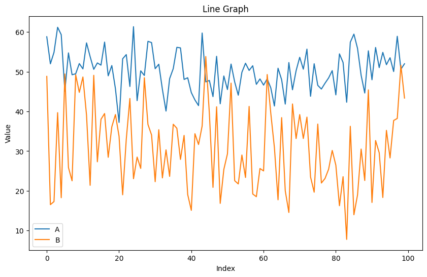

```python
# Line graph
plt.figure(figsize=(10, 6)) # Set the size of the plot
plt.plot(df['A'], label='A') # Plot the 'A' column
plt.plot(df['B'], label='B') # Plot the 'B' column
plt.xlabel('Index') # Set the x-axis label
plt.ylabel('Value') # Set the y-axis label
plt.title('Line Graph') # Set the title
plt.legend() # Show the legend
plt.show() # Show the plot
```

### Scatter Plot

Next, let's create a scatter plot.

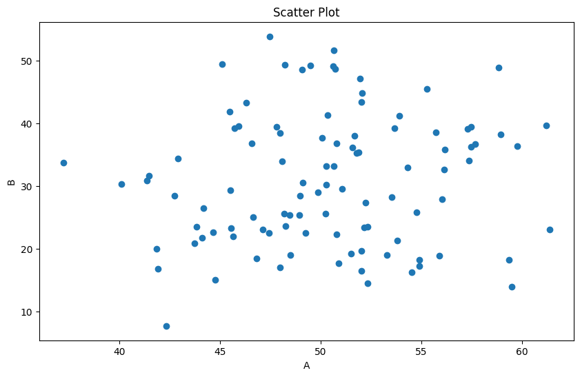

```python
# Scatter plot
plt.figure(figsize=(10, 6)) # Set the size of the plot
plt.scatter(df['A'], df['B'])    # Plot the 'A' column against the 'B' column
plt.xlabel('A') # Set the x-axis label
plt.ylabel('B') # Set the y-axis label
plt.title('Scatter Plot')   # Set the title
plt.show()  # Show the plot
```

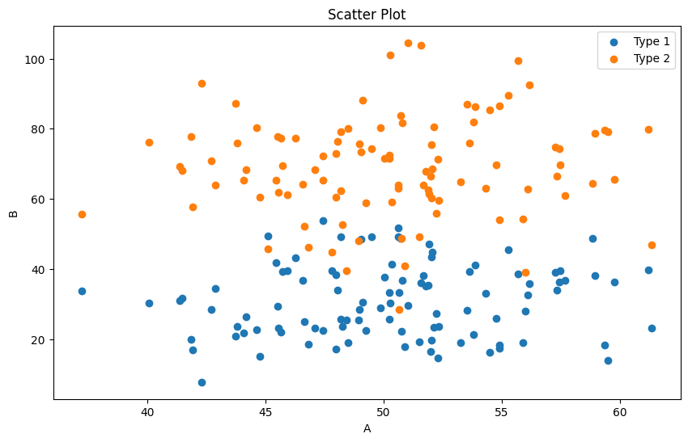

```python
# Scatter plot
plt.figure(figsize=(10, 6)) # Set the size of the plot
plt.scatter(df['A'], df['B'], label='Type 1')    # Plot the 'A' column against the 'B' column
plt.scatter(df['A'], df['C'], label='Type 2')    # Plot the 'A' column against the 'C' column
plt.legend()  # Show the legend
plt.xlabel('A') # Set the x-axis label
plt.ylabel('B') # Set the y-axis label
plt.title('Scatter Plot')   # Set the title
plt.show()  # Show the plot
```

### Bar Plot (with error bars)

Now, let's create a bar plot with error bars representing the standard error of the mean.

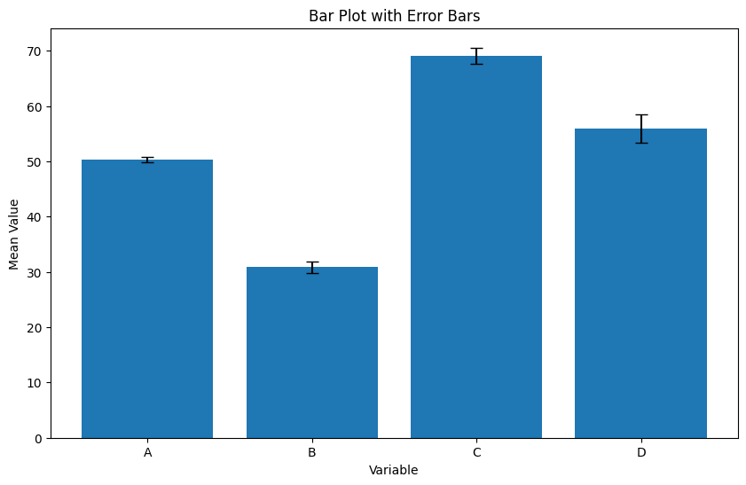

```python
# Bar plot with error bars
means = df.mean() # Calculate the mean of each column
errors = df.sem() # Calculate the standard error of the mean of each column
plt.figure(figsize=(10, 6)) # Set the size of the plot
plt.bar(means.index, means.values, yerr=errors.values, capsize=5)   # Plot the mean values with error bars
plt.xlabel('Variable')  # Set the x-axis label
plt.ylabel('Mean Value')    # Set the y-axis label
plt.title('Bar Plot with Error Bars')   # Set the title
plt.show()  # Show the plot
```

### Histogram

Let's create a histogram to visualize the distribution of data.

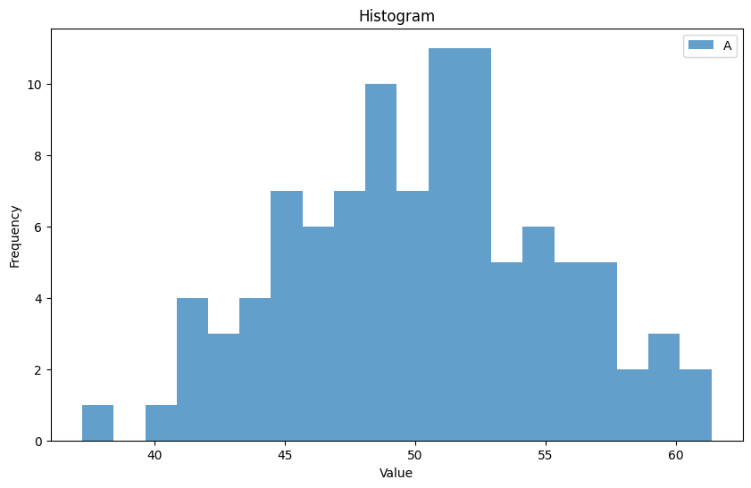

```python
# Histogram
plt.figure(figsize=(10, 6)) # Set the size of the plot
plt.hist(df['A'], bins=20, alpha=0.7, label='A') # Plot the 'A' column
plt.xlabel('Value') # Set the x-axis label
plt.ylabel('Frequency') # Set the y-axis label
plt.title('Histogram')  # Set the title
plt.legend()    # Show the legend
plt.show()  # Show the plot
```

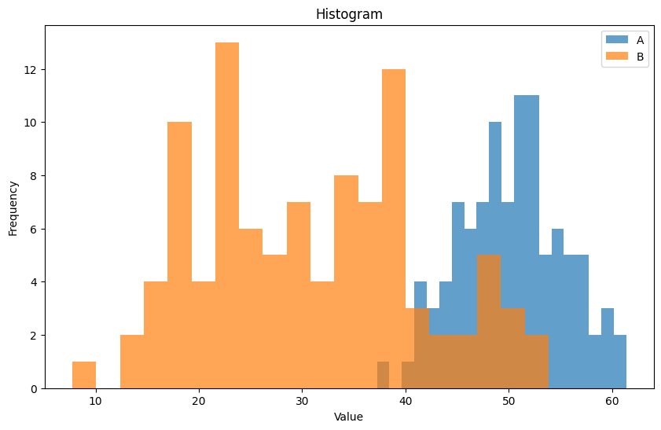

```python
# Histogram
plt.figure(figsize=(10, 6)) # Set the size of the plot
plt.hist(df['A'], bins=20, alpha=0.7, label='A') # Plot the 'A' column
plt.hist(df['B'], bins=20, alpha=0.7, label='B')    # Plot the 'B' column
plt.xlabel('Value') # Set the x-axis label
plt.ylabel('Frequency') # Set the y-axis label
plt.title('Histogram')  # Set the title
plt.legend()    # Show the legend
plt.show()  # Show the plot
```

### Subplots

Finally, let's create subplots to display multiple plots side by side.

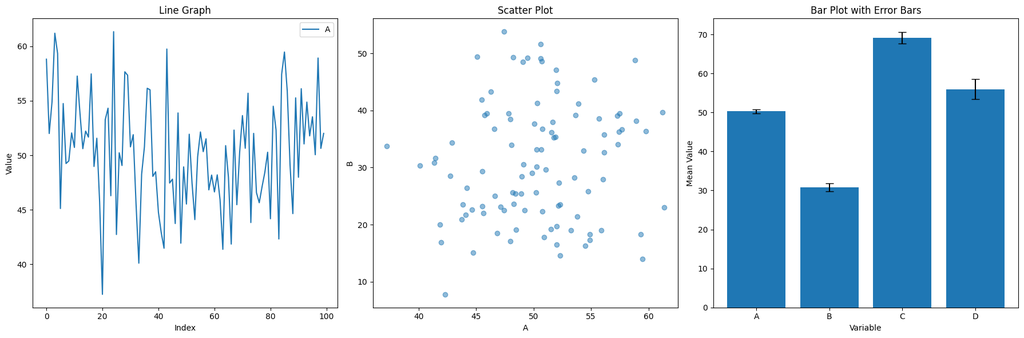

```python
# Subplots
fig, axs = plt.subplots(1, 3, figsize=(18, 6)) # Create a figure and a set of subplots. We want 1 row and 3 columns of subplots

# Line graph
axs[0].plot(df['A'], label='A') # Plot the 'A' column
axs[0].set_title('Line Graph')  # Set the title
axs[0].set_xlabel('Index')  # Set the x-axis label
axs[0].set_ylabel('Value')  # Set the y-axis label
axs[0].legend() # Show the legend

# Scatter plot
axs[1].scatter(df['A'], df['B'], alpha=0.5) # Plot the 'A' column against the 'B' column
axs[1].set_title('Scatter Plot')    # Set the title
axs[1].set_xlabel('A')  # Set the x-axis label
axs[1].set_ylabel('B')  # Set the y-axis label

# Bar plot
axs[2].bar(means.index, means.values, yerr=errors.values, capsize=5)    # Plot the mean values with error bars
axs[2].set_title('Bar Plot with Error Bars')    # Set the title
axs[2].set_xlabel('Variable')   # Set the x-axis label
axs[2].set_ylabel('Mean Value') # Set the y-axis label

plt.tight_layout()  # Adjust the subplots to fit into the figure
plt.show()  # Show the plot
```

### Double Bar Plots

A double bar plot can be used to compare two sets of data side by side.

```python
# Lets make the data for the double bar plot
data = {
    'Category': ['A', 'B', 'C', 'D'],
    'Group 1': [10, 20, 30, 40],
    'Group 2': [15, 25, 35, 45]
}

df = pd.DataFrame(data)
```

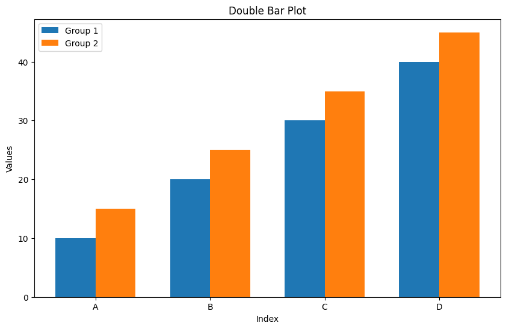

```python
# Double bar plot
plt.figure(figsize=(10, 6))
width = 0.35  # Width of the bars
x = np.arange(len(df['Category']))  # The label locations

plt.bar(x - width/2, df['Group 1'], width, label='Group 1')  # Plot the 'Group 1' bars
plt.bar(x + width/2, df['Group 2'], width, label='Group 2')  # Plot the 'Group 2' bars

plt.xticks(x, df['Category'])  # Set the x-ticks to be the 'Category' column

plt.xlabel('Index')
plt.ylabel('Values')
plt.title('Double Bar Plot')
plt.legend()
plt.show()
```